# Rapid Fire Choice Analyses

Dave Braun

7/21/2019

*This document was last updated at 2019-07-28 15:24:01.*

This document is dedicated to exploring the Experiment 2 choice data from the rapid fire phase against that from the demand selection task phase. The general purpose is to assess whether or not this choice data is usable.

Load and view the rapid fire data:

```r
dst <- read.csv('../../../data/dstClean.csv')
rapidFire <- read.csv('../../../data/rapidFireClean.csv')
rapidFire
```

[output not shown]

[output cut: 2640 more lines]

## Rapid Fire

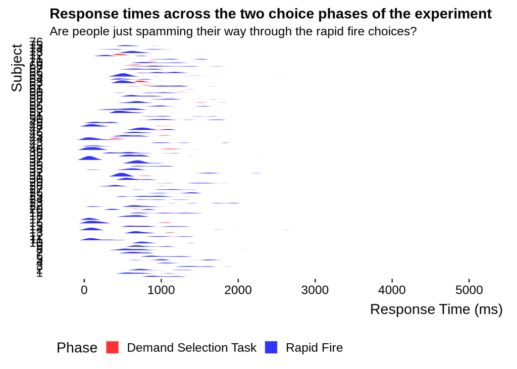

```r
dst %>%
  select(subject, choiceRt) %>%
  rename(dstChoiceRt = choiceRt) %>%
  inner_join(rapidFire) %>%
  rename(rfChoiceRt = choiceRt) %>%
  select(subject, rfChoiceRt, dstChoiceRt) %>%
  gather(phase, rt, rfChoiceRt, dstChoiceRt) %>%
  filter(rt < 5000) %>%
  mutate(subject = as.factor(subject)) %>%
  ggplot(aes(x = rt, y = subject)) +
  ## scale controls how much the densities overlap -- higher numbers = more overlap
  geom_density_ridges(aes(fill = phase), alpha = 0.8, color = 'white', scale = 1.3) +
  scale_fill_cyclical(name = 'Phase',
                      labels = c(`dstChoiceRt` = 'Demand Selection Task', `rfChoiceRt` = 'Rapid Fire'),
                      values = c('#ff0000', '#0000ff', '#ff8080', '#8080ff'), guide = 'legend') +
  theme_ridges(grid = FALSE) +
  labs(
    x = 'Response Time (ms)',
    y = 'Subject',
    title = 'Response times across the two choice phases of the experiment',
    subtitle = 'Are people just spamming their way through the rapid fire choices?'
  ) +
  theme(legend.position = 'bottom')
```

I can also try to get a sense of whether people are spamming through the rapid fire by looking at proportion selection of left / right deck throughout the phase.

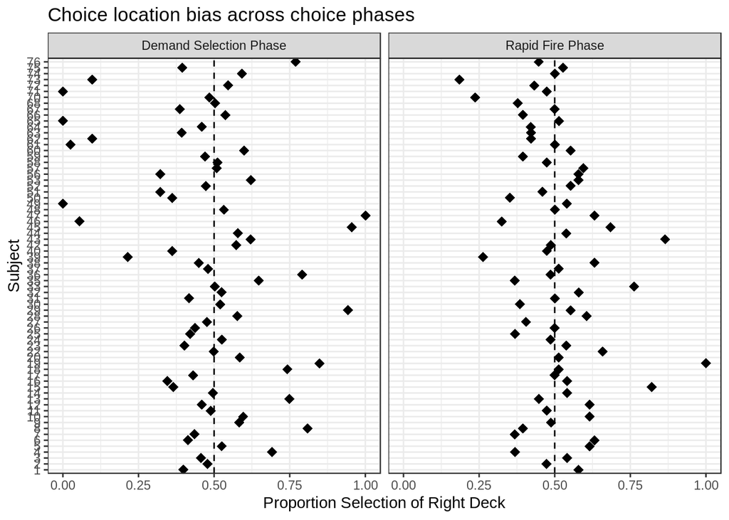

```r
rapidFire %>%
  mutate(rfChoice = ifelse(selectedDeckLocation == 'right', 1, 0)) %>%
  select(subject, rfChoice) %>%
  inner_join(dst) %>%
  mutate(dstChoice = ifelse(selectedDeckLocation == 'right', 1, 0),
         subject = as.factor(subject)) %>%
  gather(phase, isRight, rfChoice, dstChoice) %>%
  mutate(phase = as.factor(phase)) %>%
  mutate(phase = recode(phase, 'dstChoice' = 'Demand Selection Phase', 'rfChoice' = 'Rapid Fire Phase')) %>%
  group_by(subject, phase) %>%
  summarize(right = mean(isRight), sd = sd(isRight)) %>%
  ggplot(aes(x = subject, y = right)) +
  geom_point(size = 3, shape = 18) +
  #geom_errorbar(aes(ymin = right - sd, ymax = right + sd), width = 0.2) +
  geom_hline(yintercept = 0.5, linetype = 'dashed') +
  facet_wrap(~phase) +
  theme_bw() +
  coord_flip() +
  ylim(0, 1) +
  labs(
    x = 'Subject',
    y = 'Proportion Selection of Right Deck',
    title = 'Choice location bias across choice phases'
  )
```

```r
rapidFire %>%
  mutate(isRight = ifelse(selectedDeckLocation == 'right', 1, 0)) %>%
  group_by(subject) %>%
  summarize(right = mean(isRight), se = sd(isRight) / sqrt(n()), n = n())
```

| subject | right | se | n |
| --- | --- | --- | --- |
| 1 | 0.5789474 | 0.08116838 | 38 |
| 2 | 0.4722222 | 0.08438490 | 36 |
| 3 | 0.5405405 | 0.08305896 | 37 |
| 4 | 0.3684211 | 0.07930219 | 38 |
| 5 | 0.6153846 | 0.07892141 | 39 |
| 6 | 0.6315789 | 0.07930219 | 38 |
| 7 | 0.3684211 | 0.07930219 | 38 |
| 8 | 0.3947368 | 0.08035725 | 38 |
| 9 | 0.4871795 | 0.08108404 | 39 |
| 10 | 0.6153846 | 0.07892141 | 39 |

[output cut: 60 more lines]

Let’s look at choice RT in rapid fire over time. Maybe people start out thinking about it for longer and then get frustrated toward the end.

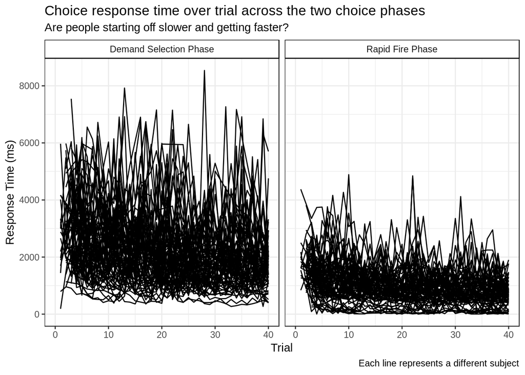

```r
a <- rapidFire %>%
  select(subject, choiceRt, choiceTrial) %>%
  mutate(phase = 'Rapid Fire Phase')

b <- dst %>%
  select(subject, choiceRt, choiceTrial) %>%
  mutate(phase = 'Demand Selection Phase')

plotData <- rbind(a, b)

plotData %>%
  ggplot(aes(x = choiceTrial, y = choiceRt, group = subject)) +
  geom_line() +
  xlim(0, 40)+
  facet_wrap(~phase) +
  labs(
    title = 'Choice response time over trial across the two choice phases',
    subtitle = 'Are people starting off slower and getting faster?',
    x = 'Trial',
    y = 'Response Time (ms)',
    caption = 'Each line represents a different subject'
  ) +
  theme_bw() +
  theme(strip.background = element_rect(fill = 'white', color = 'black'))
```

A work by [Dave Braun](https://davebraun.org)

*dab414@lehigh.edu*